# Material complementario · Taller 8

- Mostrar todo el código
- Ocultar todo el código
- Ver el código fuente

Más allá del núcleo del NMDS y el CA · Multivariados II · Semana 4

Autor/a

Javier Rodríguez-Barrios

Fecha de publicación

20 de octubre de 2026

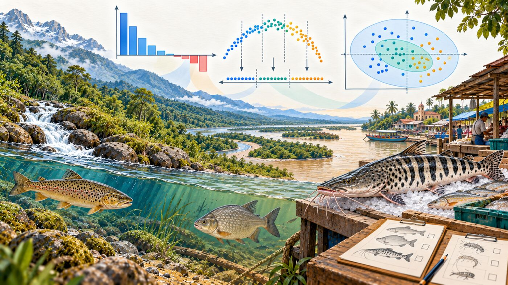

## Cómo usar este material

Este documento amplía el [Taller 8 · Ordenación de comunidades: NMDS y CA](https://javier-2712.github.io/Manuales/8.Manual_diseno_msc/html/Taller8_NMDS_CA.html). No es necesario recorrerlo completo: cada sección es independiente y responde a una situación que puede aparecer al preparar el estudio de caso o el propio proyecto de grado.

| Situación | Sección |
| --- | --- |
| Se quiere un NMDS completo de otra comunidad, con especies, variables ambientales y grupos en una figura de `ggplot2` | 1. NMDS de los peces del río Doubs |
| Se duda si dejar la transformación automática de `metaMDS()` o usar otra | 2. NMDS con otras transformaciones |
| Se necesita una ordenación con autovalores (porcentaje por eje) a partir de Bray-Curtis | 3. PCoA y autovalores negativos |
| Se quiere medir la longitud del gradiente o corregir el efecto arco del CA | 4. DCA: `decorana()` en detalle |
| Se necesitan elipses de confianza sobre el NMDS o un p honesto en `envfit()` cuando las muestras no son intercambiables | 5. Elipses y permutaciones restringidas |
| Las variables son categóricas (encuestas, rasgos cualitativos, categorías de uso) | 6. Análisis de correspondencias múltiples (MCA) |
| Se quiere que las figuras y tablas del NMDS queden guardadas en archivos al renderizar | 7. Guardado automático |
| Se quiere practicar antes del estudio de caso | 8. Ejercicios de práctica |

**Código**

```r
# Librerías requeridas
library(tidyverse)
library(readxl)
library(kableExtra)
library(vegan)
library(ggrepel)      # Rótulos sin superposición
library(FactoMineR)   # MCA (sección 6)
library(factoextra)   # Figuras del MCA (sección 6)
library(writexl)      # Guardar tablas en Excel (sección 7)

# Paletas del módulo
col_trib  <- c(T1 = "#2C6FB7", T2 = "#E3A33B", T3 = "#3E9C8F")
col_tramo <- c(Alto = "#3E9C8F", Medio = "#E3A33B", Bajo = "#2C6FB7")

# Números con uno, dos y tres decimales fijos para el texto
f1 <- function(x) formatC(x, format = "f", digits = 1)
f2 <- function(x) formatC(x, format = "f", digits = 2)
f3 <- function(x) formatC(x, format = "f", digits = 3)

# Números con coma decimal para los párrafos de reporte
coma <- function(x, d = 2) formatC(x, format = "f",
                                   digits = d,
                                   decimal.mark = ",")

# Ubicar un archivo de datos: en la carpeta del .qmd o en la raíz del proyecto
ruta_datos <- function(archivo) {
  rutas <- c(archivo, file.path("..", archivo),
             file.path("..", "..", archivo))
  ruta  <- rutas[file.exists(rutas)][1]
  if (is.na(ruta)) stop("No se encontró ", archivo,
                        ": cópielo en la carpeta de este .qmd o en la raíz del proyecto.")
  ruta
}
```

**Código**

```r
# Microalgas: matrices F, X y Y y NMDS del Taller 8
alg <- read_excel(ruta_datos("Microalgas.xlsx"), sheet = "Microalgas") %>%
  rename(Fragilaria = Fragillaria,
         Nitzschia  = Nitzchia,
         Surirella  = Surilella,
         Gyrosigma  = Girosigma,
         Achnanthes = Achnantes) %>%
  mutate(Tributario = factor(Tributario),
         Visita     = factor(as.integer(sub(".*\\.", "", Cod))))   # T1.3 → 3

F_alg <- alg %>%
  select(Cod, Tributario, Visita)
X_alg <- alg %>%
  select(Amonio:Temp)
Y_alg <- alg %>%
  select(Fragilaria:Pinnularia)

# NMDS con Bray-Curtis y la transformación automática (igual que en el Taller 8)
set.seed(2026)
nmds <- metaMDS(Y_alg, distance = "bray",
                k = 2, trymax = 100, trace = 0)
```

## 1. NMDS de los peces del río Doubs

**Pregunta:** ¿Cambia la comunidad de peces a lo largo de un río, desde la cabecera hasta la desembocadura, y qué variables acompañan ese cambio?

El río Doubs (Francia y Suiza) es un ejemplo clásico de la ecología numérica: en 30 sitios, desde la cabecera hasta la desembocadura, se registró la abundancia de 27 especies de peces y 11 variables ambientales (Verneaux, 1973; datos en Borcard et al., 2018). Es un gradiente fluvial completo, parecido al de los ríos de la Sierra Nevada de Santa Marta: aguas frías, oxigenadas y de pendiente alta arriba; aguas cálidas, lentas y con más nutrientes abajo.

**Código**

```r
# Especies (abundancias codificadas de 0 a 5) y variables ambientales
spe <- read_excel(ruta_datos("datos_nmds.xlsx"),
                  sheet = "DoubsSpe") %>%
  as.data.frame()
env <- read_excel(ruta_datos("datos_nmds.xlsx"),
                  sheet = "DoubsEnv") %>%
  as.data.frame()
rownames(spe) <- rownames(env) <- spe$Sites
spe <- spe %>%
  select(-Sites)
env <- env %>%
  select(-Sites)

# Sitios sin peces
sin_peces <- rownames(spe)[rowSums(spe) == 0]
sin_peces
```

```
[1] "8"
```

El sitio 8 no registró peces. Se elimina de las dos matrices: Bray-Curtis no está definida entre dos muestras vacías y una muestra vacía no tiene composición que ordenar.

**Código**

```r
# Eliminar el sitio sin peces y definir el tramo por la distancia a la fuente (dfs, km)
spe <- spe[rowSums(spe) > 0, ]
env <- env[rownames(spe), ]
tramo <- cut(env$dfs, breaks = c(0, 100, 250, Inf),
             labels = c("Alto", "Medio", "Bajo"))

table(tramo)
```

```
tramo
 Alto Medio  Bajo
    9    10    10
```

**Código**

```r
c(sitios = nrow(spe), especies = ncol(spe),
  ambientales = ncol(env),
  ceros = round(100 * mean(spe == 0), 1),
  max_codigo = max(spe))
```

```
     sitios    especies ambientales       ceros  max_codigo
       29.0        27.0        11.0        52.1         5.0
```

| Código | Variable | Código | Variable |
| --- | --- | --- | --- |
| `dfs` | Distancia a la fuente (km) | `har` | Dureza |
| `ele` | Elevación (m) | `pho` | Fosfatos |
| `slo` | Pendiente | `nit` | Nitratos |
| `dis` | Caudal | `amm` | Amonio |
| `pH` | pH | `oxy` | Oxígeno disuelto |
|  |  | `bod` | Demanda bioquímica de oxígeno |

**NotaTramos a partir de la distancia a la fuente**

En el material de 2024, los grupos se formaban con un análisis de clúster sobre las propias especies. Aquí se usa una variable del río, la distancia a la fuente, con cortes en 100 y 250 km: alto (9 sitios), medio (10) y bajo (10). Así los grupos no salen de la misma matriz que se ordena (la circularidad que trata el Taller 10).

### 1.1 Ajuste: estrés y estabilidad

**Código**

```r
# NMDS con Bray-Curtis para k = 1, 2 y 3
nmds_d_k <- map(1:3, function(k) {
  set.seed(2026)
  metaMDS(spe, distance = "bray",
          k = k, trymax = 100,
          trace = 0)
})
tab_k_d <- tibble(k = 1:3,
                  Estres = map_dbl(nmds_d_k, "stress"),
                  `Mejor solución repetida` = map_dbl(nmds_d_k, "converged"))

tab_k_d %>%
  kbl(booktabs = TRUE, digits = 3) %>%
  kable_classic(full_width = F) %>%
  row_spec(0, bold = TRUE)
```

| k | Estres | Mejor solución repetida |
| --- | --- | --- |
| 1 | 0.196 | 1 |
| 2 | 0.074 | 1 |
| 3 | 0.043 | 2 |

**Código**

```r
nmds_d <- nmds_d_k[[2]]
nmds_d
```

```
Call:
metaMDS(comm = spe, distance = "bray", k = k, trymax = 100, trace = 0)

global Multidimensional Scaling using monoMDS

Data:     spe
Distance: bray

Dimensions: 2
Stress:     0.07376216
Stress type 1, weak ties
Best solution was repeated 1 time in 20 tries
The best solution was from try 13 (random start)
Scaling: centring, PC rotation, halfchange scaling
Species: expanded scores based on 'spe'
```

Dos detalles de la salida:

- **`Data: spe`**: esta vez `metaMDS()` no transformó nada. La transformación automática solo se aplica cuando las abundancias son altas, y aquí son códigos de 0 a 5.
- **`Best solution was repeated 1 time`**: la mejor configuración (estrés = 0.074) no se repitió en 20 arranques. Antes de concluir que la solución es inestable, se comprueba con otra semilla y continuando desde la mejor solución:

**Código**

```r
# Otra semilla y continuación desde la mejor solución
set.seed(1)
nmds_d_otra <- metaMDS(spe, distance = "bray",
                       k = 2, trymax = 100, trace = 0)
set.seed(2026)
nmds_d_cont <- metaMDS(spe, distance = "bray",
                       k = 2, trymax = 100, trace = 0,
                       previous.best = nmds_d)

c(estres_semilla_1 = round(nmds_d_otra$stress, 5),
  r_Procrustes = round(protest(nmds_d, nmds_d_otra,
                               permutations = 0)$t0, 4),
  repeticiones_al_continuar = nmds_d_cont$converged)
```

```
         estres_semilla_1              r_Procrustes repeticiones_al_continuar
                  0.07376                   1.00000                   3.00000
```

Con otra semilla se llega al mismo estrés y a la misma configuración (correlación de Procrustes = 1.000), y al continuar desde la mejor solución esta se repite 3 veces. Las soluciones casi idénticas no cuentan como «repetidas» porque `metaMDS()` usa un criterio de convergencia muy estricto. El mensaje es una alerta para revisar, no un veredicto.

### 1.2 Especies y variables ambientales

**Código**

```r
# Ajuste de las 11 variables ambientales (999 permutaciones) y del tramo
set.seed(2026)
ef_d <- envfit(nmds_d, env, permutations = 999)
set.seed(2026)
ef_tramo <- envfit(nmds_d ~ tramo, permutations = 999)

tab_d <- tibble(Variable = names(ef_d$vectors$r),
                r2 = unname(ef_d$vectors$r),
                p  = unname(ef_d$vectors$pvals)) %>%
  mutate(p_Holm = p.adjust(p, method = "holm")) %>%
  arrange(desc(r2))

tab_d %>%
  kbl(booktabs = TRUE, digits = c(0, 2, 3, 3),
      col.names = c("Variable", "r²", "p", "p (Holm)")) %>%
  kable_classic(full_width = F) %>%
  row_spec(0, bold = TRUE)
```

| Variable | r² | p | p (Holm) |
| --- | --- | --- | --- |
| dfs | 0.75 | 0.001 | 0.011 |
| oxy | 0.74 | 0.001 | 0.011 |
| bod | 0.66 | 0.001 | 0.011 |
| ele | 0.61 | 0.001 | 0.011 |
| nit | 0.58 | 0.001 | 0.011 |
| dis | 0.57 | 0.001 | 0.011 |
| amm | 0.55 | 0.001 | 0.011 |
| pho | 0.54 | 0.001 | 0.011 |
| har | 0.38 | 0.008 | 0.024 |
| slo | 0.33 | 0.020 | 0.040 |
| pH | 0.02 | 0.782 | 0.782 |

10 de las 11 variables se sostienen con Holm. La distancia a la fuente (r² = 0.75) y el oxígeno (r² = 0.74) encabezan la lista, y el tramo explica el 51 % de la variación del mapa (r² = 0.51; p = 0.001). Solo el pH (r² = 0.02) no se asocia con la ordenación.

**AdvertenciaDiseño (RA1): un solo gradiente, muchas flechas**

En un río, casi todas las variables cambian juntas aguas abajo: la elevación baja, el caudal y los nutrientes suben, el oxígeno baja. Diez flechas significativas no son diez causas independientes, sino distintas caras del mismo gradiente longitudinal. Además, los sitios vecinos se parecen por estar cerca (autocorrelación espacial), y `envfit()` los permuta como si fueran independientes. Separar el aporte propio de cada variable es tarea de una ordenación restringida con selección de variables (Taller 9).

**Código**

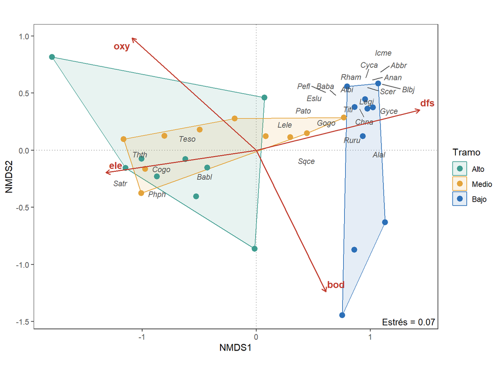

Figura 1: NMDS de los peces del río Doubs (Bray-Curtis, k = 2). Puntos: sitios, coloreados por tramo, con su polígono envolvente. Texto en cursiva: especies (promedios ponderados). Flechas: variables ambientales con r² > 0.6 en envfit, con longitud proporcional a √r².

```r
# Coordenadas de sitios, especies y polígonos por tramo
sc_d   <- as_tibble(scores(nmds_d, display = "sites"),
                    rownames = "Sitio") %>% mutate(Tramo = tramo)
sp_d   <- as_tibble(scores(nmds_d, display = "species"),
                    rownames = "Especie")
pol_d  <- sc_d %>% group_by(Tramo) %>% slice(chull(NMDS1, NMDS2))

# Flechas de las variables con r² > 0.6, reescaladas al tamaño del mapa
fl_d <- as_tibble(scores(ef_d, display = "vectors"),
                  rownames = "Variable") %>%
  filter(Variable %in% tab_d$Variable[tab_d$r2 > 0.6])
mult_d <- 0.8 * max(abs(sc_d[, c("NMDS1", "NMDS2")])) /
  max(abs(fl_d[, c("NMDS1", "NMDS2")]))

ggplot() +
  geom_hline(yintercept = 0, linetype = 3, color = "grey60") +
  geom_vline(xintercept = 0, linetype = 3, color = "grey60") +
  geom_polygon(data = pol_d, aes(NMDS1, NMDS2, fill = Tramo,
                                 color = Tramo), alpha = 0.12) +
  geom_point(data = sc_d, aes(NMDS1, NMDS2,
                              color = Tramo),
                              size = 2.8) +
  geom_text_repel(data = sp_d, aes(NMDS1, NMDS2,
                                   label = Especie),
                  fontface = "italic", size = 3,
                  color = "grey30", max.overlaps = 30) +
  geom_segment(data = fl_d, aes(x = 0, y = 0,
                                xend = NMDS1 * mult_d,
                                yend = NMDS2 * mult_d),
               arrow = arrow(length = unit(0.2, "cm")),
               color = "#C0392B", linewidth = 0.7) +
  geom_text_repel(data = fl_d, aes(NMDS1 * mult_d,
                                   NMDS2 * mult_d,
                                   label = Variable),
                  color = "#C0392B", fontface = "bold") +
  scale_color_manual(values = col_tramo) +
  scale_fill_manual(values = col_tramo) +
  coord_equal() +
  annotate("text", x = Inf, y = -Inf,
           hjust = 1.05, vjust = -0.6, size = 3.5,
           label = paste("Estrés =", f2(nmds_d$stress))) +
  theme_bw() +
  theme(panel.grid = element_blank())
```

**Código**

```r
# Especies en los dos extremos del NMDS1
sp_ord <- sp_d %>% arrange(NMDS1)
list(cabecera = head(sp_ord$Especie, 4),
     desembocadura = tail(sp_ord$Especie, 4))
```

```
$cabecera
[1] "Satr" "Thth" "Cogo" "Phph"

$desembocadura
[1] "Gyce" "Abbr" "Blbj" "Icme"
```

El NMDS1 sigue el río: los sitios del tramo alto quedan en el extremo negativo, junto a especies de aguas frías y oxigenadas como la trucha (*Satr*, *Salmo trutta*), el tímalo (*Thth*, *Thymallus thymallus*), el coto (*Cogo*, *Cottus gobio*) y el piscardo (*Phph*, *Phoxinus phoxinus*); los del tramo bajo quedan en el positivo, hacia donde apunta la distancia a la fuente, con especies de aguas cálidas y lentas como la brema (*Abbr*, *Abramis brama*), la brema blanca (*Blbj*, *Blicca bjoerkna*), la acerina (*Gyce*, *Gymnocephalus cernua*) y el pez gato negro (*Icme*, *Ameiurus melas*).

**Código**

```r
# Sitios del tramo bajo más extremos sobre el NMDS2, con sus nutrientes y la suma de códigos
vert <- sc_d %>%
  mutate(amm = env$amm, pho = env$pho,
         bod = env$bod, Suma = rowSums(spe)) %>%
  filter(Tramo == "Bajo") %>%
  arrange(NMDS2) %>%
  head(3)
vert %>%
  select(Sitio, NMDS2, amm, pho, bod, Suma) %>%
  kbl(booktabs = TRUE, digits = 2) %>%
  kable_classic(full_width = F) %>%
  row_spec(0, bold = TRUE)
```

| Sitio | NMDS2 | amm | pho | bod | Suma |
| --- | --- | --- | --- | --- | --- |
| 23 | -1.44 | 1.15 | 2.60 | 16.4 | 4 |
| 25 | -0.87 | 1.80 | 4.22 | 16.7 | 11 |
| 24 | -0.63 | 0.60 | 1.40 | 12.3 | 15 |

Dentro del tramo bajo, los sitios 23, 24, 25 se apartan hacia el extremo negativo del NMDS2, hacia donde apunta la DBO: tienen los valores más altos de amonio (hasta 1.80, frente a una mediana de 0.10 en el río) y de fosfatos, y comunidades pobres (suma de códigos de 4 a 15). Es un tramo con vertimientos: la contaminación separa a esos sitios de sus vecinos del mismo tramo.

**TipCómo reportar el resultado**

> La composición de peces de 29 sitios del río Doubs se ordenó con un NMDS sobre la disimilitud de Bray-Curtis (abundancias codificadas de 0 a 5, sin transformar; k = 2; estrés = 0,074). El primer eje ordenó los sitios desde la cabecera hasta la desembocadura y se asoció con la distancia a la fuente (envfit: r² = 0,75; p ajustado por Holm = 0,011; 999 permutaciones) y el oxígeno disuelto (r² = 0,74); el tramo explicó el 51 % de la variación del plano.

**Para discutir:** si se reemplazaran los tramos por las tres zonas de un río de la Sierra Nevada (alta, media y baja), ¿qué especies o familias ocuparían los extremos del NMDS1? ¿Qué variable haría el papel de la distancia a la fuente?

## 2. NMDS con otras transformaciones

**Pregunta:** ¿Qué cambia si se apaga la transformación automática de `metaMDS()` o se reemplaza por otra?

En el Taller 8, `metaMDS()` aplicó por su cuenta raíz cuadrada y doble estandarización de Wisconsin. Se comparan cuatro opciones sobre la misma matriz de microalgas, siempre con Bray-Curtis y k = 2:

**Código**

```r
# Cuatro versiones de la matriz de géneros
versiones <- list(
  `Automática (raíz + Wisconsin)` = list(Y = Y_alg, auto = TRUE),
  `Conteos crudos`                = list(Y = Y_alg, auto = FALSE),
  `Raíz cuadrada`                 = list(Y = sqrt(Y_alg), auto = FALSE),
  `Hellinger`                     = list(Y = decostand(Y_alg, "hellinger"), auto = FALSE)
)

# Total de individuos por muestra (escala log10), para ver si el mapa lo sigue
log_total <- data.frame(log_total = log10(rowSums(Y_alg)))

comp_tr <- imap_dfr(versiones, function(v, nombre) {
  set.seed(2026)
  m <- metaMDS(v$Y, distance = "bray", k = 2,
               trymax = 100, trace = 0,
               autotransform = v$auto)
  set.seed(2026)
  e <- envfit(m, log_total, permutations = 999)
  tibble(Transformación = nombre, Estres = m$stress,
         Repeticiones = m$converged,
         `r Procrustes con la automática` = protest(nmds, m, permutations = 0)$t0,
         `r² del total` = unname(e$vectors$r))
})

comp_tr %>%
  kbl(booktabs = TRUE, digits = c(0, 3, 0, 2, 2)) %>%
  kable_classic(full_width = F) %>%
  row_spec(0, bold = TRUE)
```

| Transformación | Estres | Repeticiones | r Procrustes con la automática | r² del total |
| --- | --- | --- | --- | --- |
| Automática (raíz + Wisconsin) | 0.119 | 9 | 1.00 | 0.88 |
| Conteos crudos | 0.054 | 3 | 0.87 | 0.99 |
| Raíz cuadrada | 0.061 | 1 | 0.94 | 0.98 |
| Hellinger | 0.110 | 1 | 0.99 | 0.89 |

Tres lecturas:

- **Un estrés menor no es un mapa mejor.** Con conteos crudos el estrés baja a 0.054, pero ese mapa sigue casi solo el número de individuos (r² del total = 0.99): las muestras con muchas algas de los géneros dominantes se parecen entre sí, y Bray-Curtis sobre conteos crudos lo refleja. El estrés mide qué tan fiel es el mapa a la distancia, no si la distancia responde la pregunta.
- **Raíz cuadrada y Hellinger** dan configuraciones parecidas a la automática (r = 0.94 y 0.99). Hellinger también convierte cada muestra en proporciones, así que es una alternativa razonable y más fácil de explicar en unos métodos que Wisconsin.
- **Incluso con Wisconsin el mapa sigue el total** (r² = 0.88). La transformación quita el total de la distancia, pero en este sustrato la composición cambia con la colonización y la abundancia también: las dos cosas van juntas en el tiempo.

**TipQué declarar en los métodos**

Se nombra la transformación aplicada (o se dice que no se transformó), la distancia y la razón ecológica: «se usó Hellinger para comparar la composición relativa sin que dominaran los géneros más abundantes» es más claro que dejar la transformación automática sin mencionarla. Si se usa la automática, se copia la línea `Data:` de la salida.

**Para discutir:** en un estudio de bentos de fondos blandos con núcleos de distinto tamaño, ¿qué transformación se elegiría y por qué?

## 3. PCoA y autovalores negativos

**Pregunta:** ¿Se puede tener una ordenación con Bray-Curtis y, al mismo tiempo, un porcentaje de varianza por eje?

El análisis de coordenadas principales (PCoA) parte, como el NMDS, de una matriz de distancias, pero en lugar de respetar el orden busca ejes que conserven las distancias mismas, como un PCA. Por eso entrega autovalores. El problema es que Bray-Curtis no es una distancia euclidiana: no siempre se puede dibujar exactamente en un espacio de ejes perpendiculares, y algunos autovalores salen **negativos**.

**Código**

```r
# PCoA de Bray-Curtis sobre los conteos (como en la diap. 21 de la presentación 08)
d_bc <- vegdist(Y_alg, method = "bray")
pcoa <- wcmdscale(d_bc, eig = TRUE)

ev <- pcoa$eig
c(autovalores = length(ev), positivos = sum(ev > 1e-8),
  negativos = sum(ev < -1e-8),
  suma_negativos = round(sum(ev[ev < 0]), 3),
  suma_positivos = round(sum(ev[ev > 0]), 3))
```

```
   autovalores      positivos      negativos suma_negativos suma_positivos
        23.000         16.000          7.000         -0.076          3.282
```

**Código**

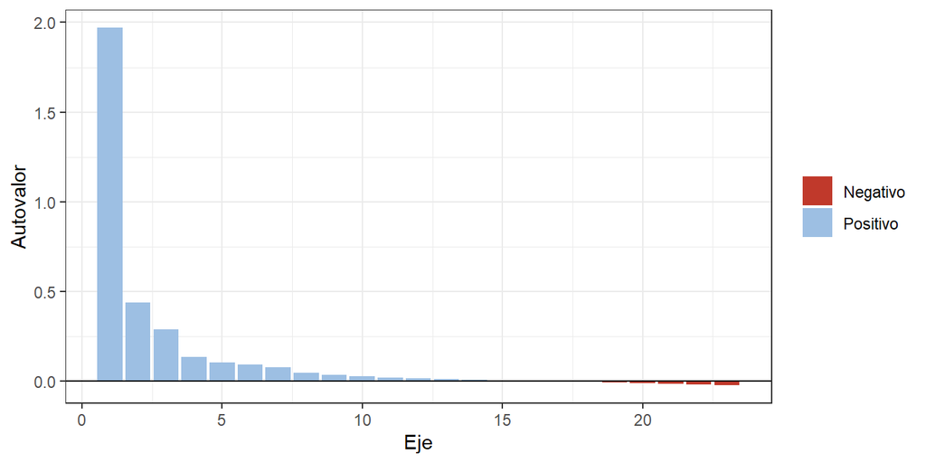

Figura 2: Autovalores del PCoA de Bray-Curtis de las microalgas. En rojo, los autovalores negativos: la parte de las distancias que no cabe en un espacio euclidiano.

```r
# Autovalores positivos y negativos
tibble(Eje = seq_along(ev), Autovalor = ev,
       Signo = ifelse(ev < 0, "Negativo", "Positivo")) %>%
  ggplot(aes(Eje, Autovalor, fill = Signo)) +
  geom_col() +
  geom_hline(yintercept = 0) +
  scale_fill_manual(values = c(Negativo = "#C0392B",
                               Positivo = "#9DBFE3")) +
  labs(x = "Eje", y = "Autovalor", fill = NULL) +
  theme_bw()
```

Hay 7 autovalores negativos, pequeños frente a los positivos (suman -0.076 frente a 3.28). Mientras sean pequeños, la ordenación es útil, pero el porcentaje por eje necesita una regla: se calcula sobre la suma de los positivos (60.0 % y 13.4 % para los dos primeros ejes) o se corrigen las distancias.

### 3.1 Correcciones de Lingoes y Cailliez

Las dos correcciones suman una constante a las distancias para que todas quepan en un espacio euclidiano (Legendre y Legendre, 2012):

**Código**

```r
# PCoA con las dos correcciones
pcoa_l <- wcmdscale(d_bc, eig = TRUE, add = "lingoes")
pcoa_c <- wcmdscale(d_bc, eig = TRUE, add = "cailliez")

pct_pc <- function(p) 100 * p$eig[1:2] / sum(p$eig[p$eig > 0])
tibble(PCoA = c("Sin corrección", "Lingoes", "Cailliez"),
       Constante = c(0, pcoa_l$ac, pcoa_c$ac),
       Negativos = c(sum(ev < -1e-8), sum(pcoa_l$eig < -1e-8),
                     sum(pcoa_c$eig < -1e-8)),
       Eje1 = c(pct_pc(pcoa)[1], pct_pc(pcoa_l)[1],
                pct_pc(pcoa_c)[1]),
       Eje2 = c(pct_pc(pcoa)[2], pct_pc(pcoa_l)[2],
                pct_pc(pcoa_c)[2])) %>%
  kbl(booktabs = TRUE, digits = c(0, 3, 0, 1, 1),
      col.names = c("PCoA", "Constante añadida", "Autovalores negativos", "Eje 1 (%)", "Eje 2 (%)")) %>%
  kable_classic(full_width = F) %>%
  row_spec(0, bold = TRUE)
```

| PCoA | Constante añadida | Autovalores negativos | Eje 1 (%) | Eje 2 (%) |
| --- | --- | --- | --- | --- |
| Sin corrección | 0.000 | 7 | 60.0 | 13.4 |
| Lingoes | 0.024 | 0 | 52.9 | 12.3 |
| Cailliez | 0.123 | 0 | 52.4 | 12.6 |

Las dos eliminan los negativos, pero a costa de inflar todas las distancias: el porcentaje del primer eje baja de 60.0 a 52.9 (Lingoes) y 52.4 % (Cailliez), porque la constante añade varianza que se reparte entre muchos ejes. Lingoes suma la constante a las distancias al cuadrado; Cailliez, a las distancias.

**NotaOtra salida: una distancia euclidiana desde el principio**

La raíz cuadrada de Bray-Curtis (`sqrt(vegdist(Y, "bray"))`) y la distancia de Hellinger son euclidianas: su PCoA no tiene autovalores negativos (y el PCoA de Hellinger es el PCA de Hellinger del Taller 8). Cuando se necesitan autovalores, se puede elegir una de ellas en lugar de corregir.

### 3.2 PCoA frente a NMDS

**Código**

```r
# PCoA con la misma disimilitud que usó el NMDS (raíz + Wisconsin y Bray-Curtis)
pcoa_w <- wcmdscale(vegdist(wisconsin(sqrt(Y_alg)), "bray"),
                    eig = TRUE)

c(NMDS_vs_PCoA_conteos   = round(protest(nmds, pcoa$points[, 1:2],
                                         permutations = 0)$t0, 2),
  NMDS_vs_PCoA_misma_dis = round(protest(nmds, pcoa_w$points[, 1:2],
                                         permutations = 0)$t0, 2))
```

```
  NMDS_vs_PCoA_conteos NMDS_vs_PCoA_misma_dis
                  0.81                   0.97
```

Con la misma disimilitud, el PCoA y el NMDS casi coinciden (r de Procrustes = 0.97); con Bray-Curtis sobre conteos crudos, la coincidencia baja a 0.81. La transformación pesa más que el método. El PCoA de esta disimilitud es la base de la db-RDA del Taller 9.

**Para discutir:** en una tabla de rasgos funcionales mixtos (talla, tipo de dieta, hábitat) con la distancia de Gower, ¿se usaría un PCoA o un NMDS? ¿Qué se reportaría de los autovalores negativos?

## 4. DCA: `decorana()` en detalle

**Pregunta:** ¿Qué hace el DCA, y cómo se usa la longitud de sus ejes para elegir entre una ordenación lineal y una unimodal?

El análisis de correspondencias sin tendencia (DCA; Hill y Gauch, 1980) es un CA con dos ajustes: corta el primer eje en segmentos y centra el segundo dentro de cada segmento (quita el arco), y reescala los ejes para que una unidad tenga el mismo significado ecológico en todo el gradiente. Esa unidad es la **desviación estándar del recambio de especies** (DE): en un gradiente de unas 4 DE, las especies de un extremo casi no aparecen en el otro.

### 4.1 Tres gradientes de distinta longitud

**Código**

```r
# Comunidad simulada del Taller 8 (30 sitios, 12 especies unimodales)
set.seed(2026)
gradiente <- seq(0, 100, length.out = 30)
optimos   <- seq(0, 100, length.out = 12)
media_sim <- outer(gradiente, optimos, function(x, o) 25 *
                     exp(-(x - o)^2 / (2 * 12^2)))
Y_sim <- matrix(rpois(length(media_sim), media_sim),
                nrow = 30)

# DCA de las tres comunidades
dca_alg <- decorana(Y_alg)
dca_d   <- decorana(spe)
dca_sim <- decorana(Y_sim)

# Longitud de un eje: rango de las coordenadas de los sitios
largo <- function(m, eje = 1) diff(range(scores(m, display = "sites")[, eje]))

tab_dca <- tibble(Comunidad = c("Microalgas del río Gaira", "Peces del río Doubs", "Simulada (Taller 8)"),
                  `DCA1 (DE)` = c(largo(dca_alg), largo(dca_d),
                                  largo(dca_sim)),
                  `DCA2 (DE)` = c(largo(dca_alg, 2), largo(dca_d, 2),
                                  largo(dca_sim, 2))) %>%
  mutate(Lectura = case_when(`DCA1 (DE)` < 3 ~ "Corto: PCA de Hellinger o RDA",
                             `DCA1 (DE)` > 4 ~ "Largo: CA o CCA",
                             TRUE ~ "Intermedio: ambas familias sirven"))

tab_dca %>%
  kbl(booktabs = TRUE, digits = 2) %>%
  kable_classic(full_width = F) %>%
  row_spec(0, bold = TRUE)
```

| Comunidad | DCA1 (DE) | DCA2 (DE) | Lectura |
| --- | --- | --- | --- |
| Microalgas del río Gaira | 1.64 | 1.43 | Corto: PCA de Hellinger o RDA |
| Peces del río Doubs | 3.86 | 1.47 | Intermedio: ambas familias sirven |
| Simulada (Taller 8) | 6.76 | 2.23 | Largo: CA o CCA |

Las microalgas tienen un gradiente corto (1.6 DE): casi todos los géneros están en casi todas las muestras. El Doubs, con 3.9 DE, queda en la zona intermedia: de la cabecera a la desembocadura cambian muchas especies, pero no todas. La comunidad simulada (6.8 DE) tiene un gradiente largo: las especies de un extremo no se encuentran en el otro.

**ImportanteUna regla práctica, no una prueba**

Los umbrales de 3 y 4 DE son orientativos (Legendre y Legendre, 2012). La longitud depende del número de segmentos y de las especies raras, y el DCA no tiene prueba de hipótesis. Se usa para **elegir la familia de técnicas** (lineal o unimodal), no para reportar resultados: hoy se prefiere reportar un NMDS, un CA o un PCA de Hellinger y usar el DCA solo como diagnóstico.

### 4.2 El arco y su corrección

**Código**

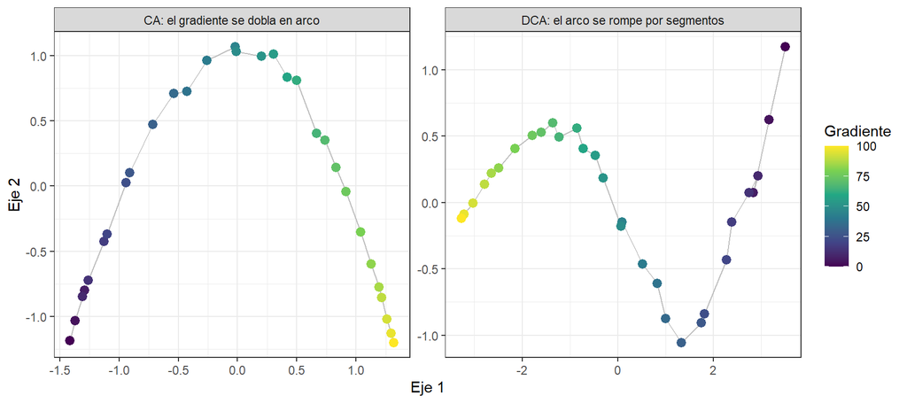

Figura 3: La comunidad simulada del Taller 8 ordenada con un CA (izquierda) y con un DCA (derecha). El color indica la posición real de cada sitio en el gradiente.

```r
# Coordenadas del CA y del DCA de la comunidad simulada
ca_sim <- cca(Y_sim)
bind_rows(
  as_tibble(scores(ca_sim, display = "sites", scaling = 1),
            .name_repair = ~ c("Eje1", "Eje2")) %>%
    mutate(Técnica = "CA: el gradiente se dobla en arco"),
  as_tibble(scores(dca_sim, display = "sites")[, 1:2],
            .name_repair = ~ c("Eje1", "Eje2")) %>%
    mutate(Técnica = "DCA: el arco se rompe por segmentos")
) %>%
  mutate(Gradiente = rep(gradiente, 2)) %>%
  ggplot(aes(Eje1, Eje2, color = Gradiente)) +
  geom_path(color = "grey75") +
  geom_point(size = 2.8) +
  scale_color_viridis_c() +
  facet_wrap(~ Técnica, scales = "free") +
  labs(x = "Eje 1", y = "Eje 2") +
  theme_bw()
```

**Código**

```r
# ¿Cuánto depende el eje 2 del cuadrado del eje 1? (correlación cercana a ±1 = arco)
arco <- function(sc) cor(sc[, 1]^2, sc[, 2])
c(CA  = round(arco(scores(ca_sim, display = "sites",
                          scaling = 1)), 2),
  DCA = round(arco(scores(dca_sim, display = "sites")), 2))
```

```
   CA   DCA
-0.99  0.28
```

En el CA, el segundo eje es casi una función del cuadrado del primero (r = -0.99). En el DCA esa dependencia se debilita (r = 0.28) y el primer eje recupera el orden del gradiente (con el signo invertido, que es arbitrario), pero el segundo eje no queda plano: el centrado por segmentos cambia el arco por una ondulación. Es una de las críticas al DCA (Minchin, 1987): corrige un artefacto introduciendo otro, y por eso el eje 2 del DCA no se interpreta.

### 4.3 Reducir el peso de las raras

**Código**

```r
# DCA con y sin reducción del peso de las especies raras
dca_alg_iw <- decorana(Y_alg, iweigh = 1)

rbind(sin_reduccion = scores(dca_alg,
                             display = "species")["Cymbella", 1:2],
      con_iweigh    = scores(dca_alg_iw,
                             display = "species")["Cymbella", 1:2]) %>%
  round(2)
```

```
               DCA1 DCA2
sin_reduccion -1.29 4.01
con_iweigh    -1.29 4.00
```

**Código**

```r
c(DCA1_sin = round(largo(dca_alg), 2),
  DCA1_con = round(largo(dca_alg_iw), 2))
```

```
DCA1_sin DCA1_con
    1.64     1.64
```

`iweigh = 1` baja el peso de las especies presentes en menos de una quinta parte de la frecuencia máxima. *Cymbella* (4 de 24 muestras) es la única afectada, y su posición casi no cambia: con un gradiente corto y una sola especie rara, la reducción no hace diferencia. Recuérdese del Taller 8 que el eje dominante del CA lo tiraba *Lyngbya*, que no es rara: `iweigh` no ayuda con los perfiles peculiares.

**Para discutir:** el Doubs mide 3.9 DE. ¿Se reportaría para esa matriz un CA, un PCA de Hellinger o un NMDS? ¿Qué argumento iría en los métodos?

## 5. Elipses y permutaciones restringidas sobre el NMDS

**Pregunta:** ¿Cómo se dibujan elipses con significado estadístico sobre un NMDS, y cómo cambia el p de `envfit()` cuando se respeta que las visitas no son intercambiables?

### 5.1 `ordiellipse()`: error estándar frente a desviación estándar

En el Taller 8 los tributarios se envolvieron con polígonos (`chull()`), que solo muestran la extensión de las muestras. `ordiellipse()` dibuja elipses calculadas con la covarianza de las coordenadas de cada grupo:

**Código**

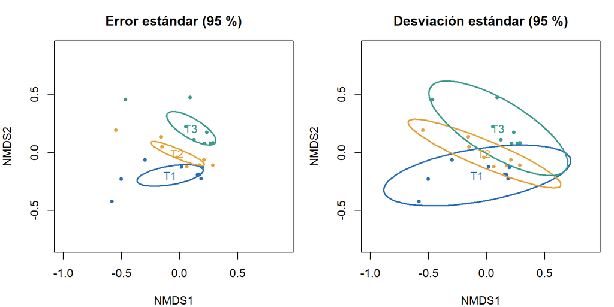

Figura 4: NMDS de microalgas con elipses por tributario. Izquierda: elipse de error estándar al 95 % (confianza del centroide). Derecha: elipse de desviación estándar al 95 % (dispersión de las muestras).

```r
# Dos paneles con vegan base
par(mfrow = c(1, 2), mar = c(4, 4, 3, 1))
for (tipo in c("se", "sd")) {
  plot(nmds, type = "n", xlim = c(-1, 0.9), ylim = c(-0.6, 0.7),
       main = ifelse(tipo == "se",
                     "Error estándar (95 %)",
                     "Desviación estándar (95 %)"))
  points(nmds, display = "sites", pch = 19,
         col = col_trib[F_alg$Tributario])
  ordiellipse(nmds, F_alg$Tributario, kind = tipo, conf = 0.95,
              col = col_trib, lwd = 2, label = TRUE)
}
par(mfrow = c(1, 1))
```

| `kind` | Describe | Con más muestras | Se usa para |
| --- | --- | --- | --- |
| `"se"` | Incertidumbre del **centroide** del grupo | Se achica | Comparar centroides (equivale a la elipse de confianza del Taller 7) |
| `"sd"` | Dispersión de las **muestras** del grupo | No se achica | Mostrar dónde cae la mayoría de las muestras |

### 5.2 Las mismas elipses en `ggplot2`

`ordiellipse()` devuelve, para cada grupo, el centro, la covarianza y el factor de escala. Con eso se reconstruye la elipse en una tabla:

**Código**

```r
# Elipses de error estándar sin dibujar (draw = "none")
el_se <- ordiellipse(nmds, F_alg$Tributario,
                     kind = "se",
                     conf = 0.95,
                     draw = "none")

# Puntos de la elipse a partir del centro, la covarianza y la escala
puntos_elipse <- function(e, n = 100) {
  ang  <- seq(0, 2 * pi, length.out = n)
  circ <- cbind(cos(ang), sin(ang))
  Q    <- chol(e$cov, pivot = TRUE)
  o    <- attr(Q, "pivot")
  pts  <- t(e$center + e$scale * t(circ %*% Q[, o]))
  tibble(NMDS1 = pts[, 1], NMDS2 = pts[, 2])
}
elip_se <- imap_dfr(el_se, ~ puntos_elipse(.x) %>%
                      mutate(Tributario = .y))

# Coordenadas de las muestras
sc_nmds <- as_tibble(scores(nmds, display = "sites")) %>%
  bind_cols(F_alg)
```

**Código**

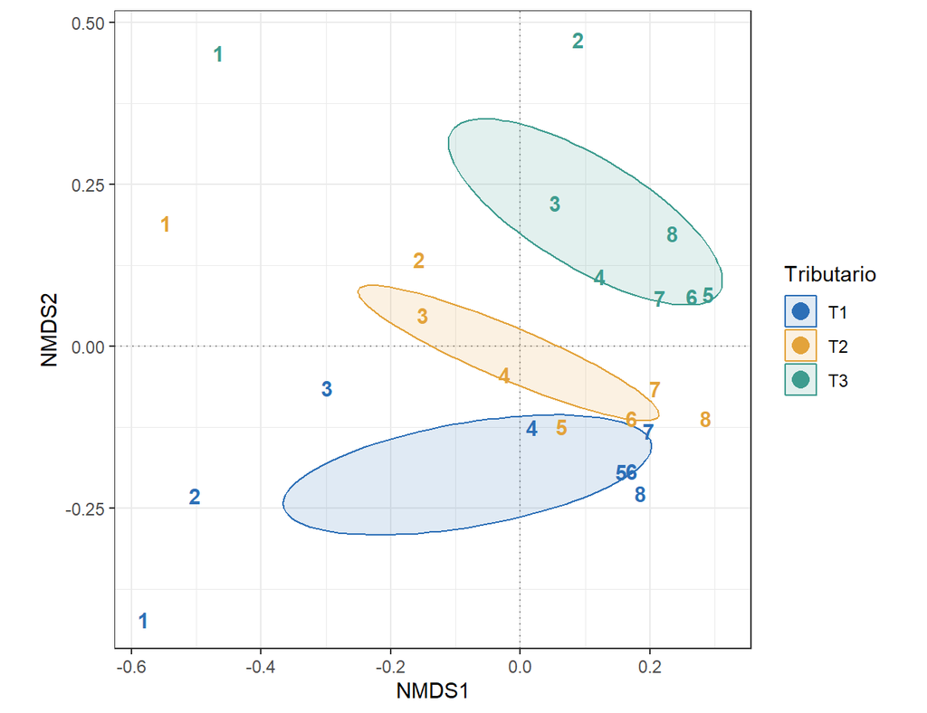

Figura 5: NMDS de microalgas con elipses de error estándar al 95 % por tributario, construidas en ggplot2 a partir de ordiellipse(). Números: visita.

```r
ggplot() +
  geom_hline(yintercept = 0, linetype = 3, color = "grey60") +
  geom_vline(xintercept = 0, linetype = 3, color = "grey60") +
  geom_polygon(data = elip_se, aes(NMDS1, NMDS2,
                                   fill = Tributario,
                                   color = Tributario),
               alpha = 0.15) +
  geom_text(data = sc_nmds, aes(NMDS1, NMDS2,
                                label = Visita,
                                color = Tributario),
            fontface = "bold", key_glyph = "point") +
  scale_color_manual(values = col_trib) +
  scale_fill_manual(values = col_trib) +
  coord_equal() +
  theme_bw()
```

Las elipses de T3 y T1 quedan separadas; la de T2 queda entre ambas y toca la de T1 en el extremo derecho, donde convergen las visitas tardías. Es una lectura descriptiva, con las mismas reservas de la Advertencia RA1 del Taller 8.

### 5.3 `envfit()` con permutaciones dentro de cada visita

El material complementario del Taller 7 (sección 5) mostró el efecto de los bloques sobre un PCA. Aquí se aplica al NMDS y a las diez variables ambientales del Taller 8. Las tres muestras de una misma visita se tomaron en la misma semana; la permutación por bloques solo reasigna valores **dentro** de cada visita:

**Código**

```r
# Diseño de permutación: libre dentro de cada visita
h_vis <- how(nperm = 999, blocks = F_alg$Visita)

# Variables ambientales con permutación libre y por bloques
set.seed(2026)
ef_libre <- envfit(nmds, X_alg, permutations = 999)
set.seed(2026)
ef_bloq  <- envfit(nmds, X_alg, permutations = h_vis)

tab_bloq <- tibble(Variable = names(ef_libre$vectors$r),
                   r2 = unname(ef_libre$vectors$r),
                   p_libre = unname(ef_libre$vectors$pvals),
                   p_bloques = unname(ef_bloq$vectors$pvals)) %>%
  mutate(Holm_libre = p.adjust(p_libre, "holm"),
         Holm_bloques = p.adjust(p_bloques, "holm")) %>%
  arrange(p_bloques)

tab_bloq %>%
  kbl(booktabs = TRUE, digits = c(0, 2, 3, 3, 3, 3),
      col.names = c("Variable", "r²",
                    "p libre",
                    "p bloques",
                    "Holm libre",
                    "Holm bloques")) %>%
  kable_classic(full_width = F) %>%
  row_spec(0, bold = TRUE)
```

| Variable | r² | p libre | p bloques | Holm libre | Holm bloques |
| --- | --- | --- | --- | --- | --- |
| Conductividad | 0.49 | 0.003 | 0.001 | 0.030 | 0.010 |
| Temp | 0.39 | 0.011 | 0.002 | 0.099 | 0.018 |
| Nitrito | 0.17 | 0.139 | 0.096 | 0.973 | 0.768 |
| Caudal | 0.15 | 0.212 | 0.112 | 1.000 | 0.784 |
| Vel_Corriente | 0.09 | 0.389 | 0.147 | 1.000 | 0.882 |
| Luz | 0.18 | 0.112 | 0.257 | 0.896 | 1.000 |
| Oxigeno | 0.02 | 0.848 | 0.650 | 1.000 | 1.000 |
| pH | 0.13 | 0.245 | 0.667 | 1.000 | 1.000 |
| Nitrato | 0.01 | 0.933 | 0.741 | 1.000 | 1.000 |
| Amonio | 0.02 | 0.762 | 0.996 | 1.000 | 1.000 |

**Código**

```r
# El tributario con los dos diseños
set.seed(2026)
ef_t_libre <- envfit(nmds ~ Tributario,
                     data = F_alg, permutations = 999)
set.seed(2026)
ef_t_bloq  <- envfit(nmds ~ Tributario,
                     data = F_alg, permutations = h_vis)

c(r2 = round(ef_t_libre$factors$r, 2),
  p_libre = ef_t_libre$factors$pvals,
  p_bloques = ef_t_bloq$factors$pvals)
```

```
       r2.Tributario   p_libre.Tributario p_bloques.Tributario
               0.280                0.011                0.001
```

**Código**

```r
# Valores para el texto
tb <- function(v, col) tab_bloq[[col]][tab_bloq$Variable == v]
```

El r² no cambia; cambia la distribución con la que se compara. Con bloques, la temperatura baja de p = 0.011 a 0.002 y **se sostiene con Holm** (0.018, frente a 0.10 con permutación libre). El tributario pasa de p = 0.011 a 0.001.

¿Por qué los bloques **aumentan** la evidencia? Porque la permutación libre mezcla visitas tempranas con tardías, y la composición cambia mucho con la colonización: esa variación entre visitas entra en la distribución de referencia y la vuelve más dispersa. Al permutar dentro de cada visita, la comparación se hace entre tributarios de la misma semana, que es la pregunta del diseño. Restringir las permutaciones no siempre baja la significancia; la vuelve **honesta**. Es la lógica de la PERMANOVA con la visita como bloque del Taller 10.

**Para discutir:** si la temperatura se sostiene con bloques, ¿se puede decir que la temperatura **causa** las diferencias en composición? ¿Qué otra variable cambia entre tributarios en la misma semana?

## 6. Análisis de correspondencias múltiples (MCA)

**Pregunta:** ¿Qué combinaciones de prácticas de comercialización caracterizan los registros de bagres en Colombia, y se asocian con la especie o el precio?

El MCA es la versión del CA para tablas de **variables categóricas**: encuestas, rasgos cualitativos, categorías de uso del suelo o de captura. Se usa la base `bagres.xlsx`: 100 registros de comercialización de bagres (*Pseudoplatystoma* spp.) tomados al azar de las encuestas del Servicio Estadístico Pesquero Colombiano (SEPEC, 2021; datos en Rodríguez-Barrios, 2023), con 14 variables categóricas codificadas.

### 6.1 Depurar antes de ordenar

**Código**

```r
# Base de bagres y variables categóricas de la encuesta
bagres <- read_excel(ruta_datos("bagres.xlsx"),
                     .name_repair = "unique_quiet")
cat_bag <- bagres %>% select(Importado:Cliente.ter.)

# Número de categorías de cada variable
sapply(cat_bag, function(x) length(unique(x)))
```

```
    Importado        Origen       Destino     Tipo.prod     Proveedor
            2             2             2             1             3
     Sit.comp   Frec.compra     Transform       Conserv       Empaque
            6             3             3             2             3
   Transporte Cliente.prim.  Cliente.sec.  Cliente.ter.
            3             3             5             5
```

Tres problemas aparecen antes de cualquier análisis:

**Código**

```r
# 1. Una variable sin variación
table(bagres$Tipo.prod)
```

```
Tipo.prod.p
        100
```

**Código**

```r
# 2. Dos variables que son la misma
table(bagres$Importado, bagres$Origen)
```

```
              Origen.i Origen.n
  Importado.F        0       93
  Importado.v        7        0
```

**Código**

```r
# 3. Una variable con dos codificaciones de la misma categoría
table(bagres$Sit.comp)
```

```
     Sit.comp.c      Sit.comp.o  Sitio.compra.c  Sitio.compra.o Sitio.compra.pm
              1               9              51              10              18
Sitio.compra.pu
             11
```

1. `Tipo.prod` tiene una sola categoría: no aporta información y se elimina.
2. `Importado` y `Origen` coinciden registro a registro (los 7 importados son los mismos 7 de origen «i»): mantener las dos contaría dos veces lo mismo. Se deja `Importado`.
3. `Sit.comp` mezcla los prefijos `Sit.comp.` y `Sitio.compra.` para las mismas categorías (`c` y `o`). Se unifican.

**Código**

```r
# Variables activas depuradas, como factores
act <- cat_bag %>%
  select(-Tipo.prod, -Origen) %>%
  mutate(Sit.comp = sub("^Sitio\\.compra\\.",
                        "Sit.comp.", Sit.comp)) %>%
  mutate(across(everything(), factor))

c(variables = ncol(act),
  categorias = sum(sapply(act, nlevels)),
  dimensiones = sum(sapply(act, nlevels)) - ncol(act))
```

```
  variables  categorias dimensiones
         12          38          26
```

### 6.2 El MCA es un CA de la tabla disyuntiva

Cada variable se convierte en tantas columnas de 0 y 1 como categorías tenga (tabla disyuntiva completa). El MCA es el CA de esa tabla:

**Código**

```r
# MCA con FactoMineR y CA de la tabla disyuntiva con vegan
mca <- MCA(act, graph = FALSE)
Z_bag <- tab.disjonctif(act)

rbind(MCA = mca$eig[1:4, 1],
      CA_disyuntiva = unname(eigenvals(cca(Z_bag))[1:4])) %>%
  round(4)
```

```
               dim 1  dim 2  dim 3 dim 4
MCA           0.3962 0.2225 0.1837 0.163
CA_disyuntiva 0.3962 0.2225 0.1837 0.163
```

Los autovalores coinciden: todo lo visto del CA en el Taller 8 (inercia, perfiles, peso de lo peculiar) vale para el MCA. Con 12 variables y 38 categorías hay 26 dimensiones.

### 6.3 Autovalores y corrección de Benzécri

**Código**

```r
# Porcentaje de inercia y corrección de Benzécri (solo autovalores > 1/Q)
Q  <- ncol(act)
ev_mca <- mca$eig[, 1]
bz <- ifelse(ev_mca > 1 / Q, ((Q / (Q - 1)) * (ev_mca - 1 / Q))^2, 0)

tab_mca <- tibble(Dimensión = 1:5,
                  Autovalor = unname(ev_mca[1:5]),
                  `% inercia` = unname(mca$eig[1:5, 2]),
                  `% Benzécri` = unname(100 * bz[1:5] / sum(bz)))

tab_mca %>%
  kbl(booktabs = TRUE, digits = c(0, 3, 1, 1)) %>%
  kable_classic(full_width = F) %>%
  row_spec(0, bold = TRUE)
```

| Dimensión | Autovalor | % inercia | % Benzécri |
| --- | --- | --- | --- |
| 1 | 0.396 | 18.3 | 68.9 |
| 2 | 0.223 | 10.3 | 13.7 |
| 3 | 0.184 | 8.5 | 7.1 |
| 4 | 0.163 | 7.5 | 4.5 |
| 5 | 0.148 | 6.8 | 2.9 |

En un MCA, el porcentaje de inercia es pesimista: la tabla disyuntiva añade una inercia artificial (cada registro tiene exactamente un 1 por variable), y los primeros ejes parecen recoger poco (18.3 % la dimensión 1). La corrección de Benzécri considera solo los autovalores mayores que 1/Q = 0.083 y da una idea más realista: 68.9 % para la dimensión 1 (Greenacre, 2017). Se reporta cuál de los dos se usa.

### 6.4 Qué define cada dimensión

**Código**

```r
# Relación de cada variable con las dos primeras dimensiones (eta²)
as_tibble(mca$var$eta2[, 1:2], rownames = "Variable") %>%
  arrange(desc(`Dim 1`)) %>%
  kbl(booktabs = TRUE, digits = 2,
      col.names = c("Variable", "η² Dim 1", "η² Dim 2")) %>%
  kable_classic(full_width = F) %>%
  row_spec(0, bold = TRUE)
```

| Variable | η² Dim 1 | η² Dim 2 |
| --- | --- | --- |
| Sit.comp | 0.84 | 0.11 |
| Proveedor | 0.76 | 0.13 |
| Importado | 0.66 | 0.02 |
| Empaque | 0.54 | 0.25 |
| Transporte | 0.53 | 0.16 |
| Transform | 0.35 | 0.13 |
| Frec.compra | 0.34 | 0.21 |
| Cliente.sec. | 0.33 | 0.53 |
| Cliente.prim. | 0.23 | 0.50 |
| Cliente.ter. | 0.14 | 0.47 |
| Conserv | 0.04 | 0.06 |
| Destino | 0.00 | 0.09 |

**Código**

```r
# Categorías con mayor contribución a la dimensión 1 y su frecuencia
contr1 <- sort(mca$var$contrib[, 1], decreasing = TRUE)[1:5]
tibble(Categoría = names(contr1), `Contribución (%)` = unname(contr1),
       Registros = colSums(Z_bag)[names(contr1)]) %>%
  kbl(booktabs = TRUE, digits = 1) %>%
  kable_classic(full_width = F) %>%
  row_spec(0, bold = TRUE)
```

| Categoría | Contribución (%) | Registros |
| --- | --- | --- |
| Sit.comp.pu | 15.5 | 11 |
| Proveedor.pa | 14.7 | 8 |
| Importado.v | 12.9 | 7 |
| Transporte.m | 10.4 | 6 |
| Empaque.cf | 8.5 | 7 |

La dimensión 1 la construyen pocas categorías poco frecuentes: el bagre importado (7 registros), un tipo de proveedor y un sitio de compra que casi solo aparecen con él. Es el mismo fenómeno de *Lyngbya* en el CA del Taller 8: pocos registros con un perfil peculiar ocupan un eje entero.

**Código**

```r
# ¿Dónde se registraron los bagres importados?
table(bagres$Municipios[bagres$Importado == "Importado.v"])
```

```
       Leticia Puerto Carreño
             6              1
```

Los importados se registraron en municipios de frontera (Leticia y Puerto Carreño): la dimensión 1 separa el comercio de frontera del comercio interno.

### 6.5 Variables suplementarias: especie, municipio, volumen y precio

Las variables suplementarias no construyen los ejes; se proyectan después, como `envfit()` sobre un NMDS:

**Código**

```r
# MCA con variables suplementarias: dos cualitativas y dos cuantitativas
d_bag <- data.frame(Bagre     = factor(bagres$Nombre.vernacular),
                    Municipio = factor(bagres$Municipios),
                    log_venta_kg = log10(bagres$Venta.kg),       # Venta muy sesgada
                    Precio_miles = bagres$Precio.venta / 1000,
                    act)

mca_sup <- MCA(d_bag, quali.sup = 1:2, quanti.sup = 3:4, graph = FALSE)

# Correlación de las cuantitativas con las dos primeras dimensiones
round(mca_sup$quanti.sup$coord[, 1:2], 2)
```

```
             Dim 1 Dim 2
log_venta_kg  0.39  0.51
Precio_miles -0.64 -0.02
```

**Código**

```r
# Asociación de las cualitativas suplementarias con las dimensiones (η²)
round(mca_sup$quali.sup$eta2[, 1:2], 2)
```

```
          Dim 1 Dim 2
Bagre      0.09  0.09
Municipio  0.87  0.53
```

**Código**

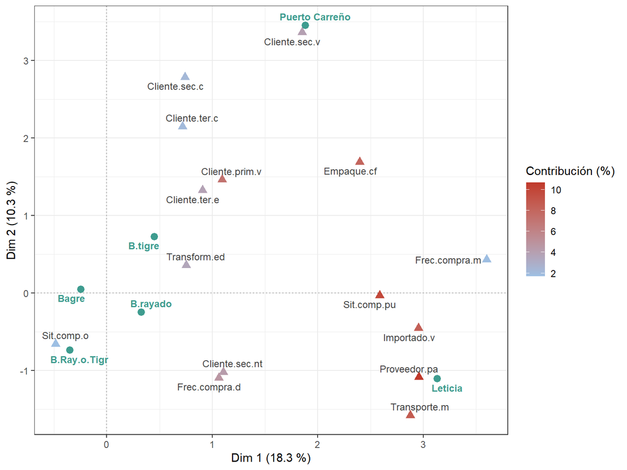

Figura 6: MCA de las prácticas de comercialización de bagres. Triángulos: las 15 categorías activas con mayor contribución al plano, coloreadas por esa contribución. En verde: categorías suplementarias del nombre vernáculo y de los dos municipios de frontera.

```r
# Categorías activas: las 15 con mayor contribución al plano Dim 1–Dim 2
ctr_plano <- mca_sup$var$contrib[, 1] * mca_sup$eig[1, 1] + mca_sup$var$contrib[, 2] * mca_sup$eig[2, 1]
cat_act <- as_tibble(mca_sup$var$coord[, 1:2], rownames = "Categoría") %>%
  mutate(Contribución = ctr_plano / sum(ctr_plano) * 100) %>%
  slice_max(Contribución, n = 15)

# Categorías suplementarias: nombre vernáculo y municipios de frontera
cat_sup <- as_tibble(mca_sup$quali.sup$coord[, 1:2], rownames = "Categoría") %>%
  filter(Categoría %in% c(levels(d_bag$Bagre), "Leticia", "Puerto Carreño"))

# Rótulos de las dos clases de categorías en una sola tabla
rotulos <- bind_rows(cat_act %>% mutate(Color = "grey25", Letra = "plain"),
                     cat_sup %>% mutate(Color = "#3E9C8F", Letra = "bold"))

ggplot() +
  geom_hline(yintercept = 0, linetype = 3, color = "grey60") +
  geom_vline(xintercept = 0, linetype = 3, color = "grey60") +
  geom_point(data = cat_act, aes(`Dim 1`, `Dim 2`, color = Contribución), shape = 17, size = 2.8) +
  geom_point(data = cat_sup, aes(`Dim 1`, `Dim 2`), color = "#3E9C8F", size = 2.8) +
  # Un solo juego de rótulos para que activas y suplementarias no se superpongan
  geom_text_repel(data = rotulos, aes(`Dim 1`, `Dim 2`, label = Categoría),
                  color = rotulos$Color, fontface = rotulos$Letra, size = 3.2,
                  max.overlaps = 30) +
  scale_color_gradient(low = "#9DBFE3", high = "#C0392B", name = "Contribución (%)") +
  labs(x = paste0("Dim 1 (", f1(mca_sup$eig[1, 2]), " %)"),
       y = paste0("Dim 2 (", f1(mca_sup$eig[2, 2]), " %)")) +
  theme_bw()
```

El precio se opone a la dimensión 1 (r = -0.64): el bagre importado de frontera se registró con un precio menor (mediana de 12.000 frente a 20.000 pesos). El volumen vendido se asocia más con la dimensión 2 (r = 0.51) que con la 1 (r = 0.39). El municipio se asocia con fuerza con la dimensión 1 (η² = 0.87, aunque con 10 categorías un η² alto es más fácil de obtener), mientras que el nombre vernáculo apenas se relaciona con las dimensiones (η² ≤ 0.09): las prácticas de comercialización dependen más del lugar que de la especie.

### 6.6 Categorías raras: ventilación

**Código**

```r
# MCA repartiendo al azar las categorías con menos del 5 % de los registros
set.seed(2026)
mca_v <- MCA(act, graph = FALSE, level.ventil = 0.05)

# ¿Se conserva la dimensión 1? Correlación de las coordenadas de los registros
r_dim1 <- abs(cor(mca$ind$coord[, 1], mca_v$ind$coord[, 1]))

tibble(MCA = c("Todas las categorías", "Ventilación < 5 %"),
       Categorías = c(nrow(mca$var$coord), nrow(mca_v$var$coord)),
       `Dim 1 (%)` = c(mca$eig[1, 2], mca_v$eig[1, 2]),
       `Dim 2 (%)` = c(mca$eig[2, 2], mca_v$eig[2, 2])) %>%
  kbl(booktabs = TRUE, digits = 1) %>%
  kable_classic(full_width = F) %>%
  row_spec(0, bold = TRUE)
```

| MCA | Categorías | Dim 1 (%) | Dim 2 (%) |
| --- | --- | --- | --- |
| Todas las categorías | 38 | 18.3 | 10.3 |
| Ventilación < 5 % | 30 | 24.5 | 12.8 |

`level.ventil` reasigna al azar, entre las demás categorías de la misma variable, los registros de las categorías con menos del 5 % de frecuencia. Es el equivalente en el MCA de filtrar las especies raras en un CA. Las categorías bajan de 38 a 30, pero la dimensión 1 se conserva (correlación de las coordenadas de los registros con y sin ventilación = 0.99), porque las categorías del grupo de frontera superan el umbral (el bagre importado tiene 7 registros): no es un artefacto de una categoría aislada, sino un grupo pequeño y coherente.

**AdvertenciaDiseño (RA1): registros de una encuesta**

Los 100 registros se tomaron al azar de una base mayor, pero un mismo comercializador o municipio puede aportar varios registros, y las categorías están codificadas sin un diccionario en la base. Antes de un MCA propio se documenta el significado de cada código y se revisa si la unidad de análisis es el registro, el comercializador o el municipio.

**Para discutir:** en un estudio de pesca artesanal en Taganga o en la Ciénaga Grande, ¿qué variables categóricas se podrían ordenar con un MCA (arte de pesca, sitio de desembarco, destino de la captura)? ¿Qué variable cuantitativa se proyectaría como suplementaria?

## 7. Guardado automático de figuras y tablas

**Pregunta:** ¿Cómo se obtienen las tablas del NMDS y sus figuras como archivos para la tesis o el artículo?

El bloque que guarda **todas** las figuras al renderizar (`knitr::opts_chunk$set(fig.path = ...)`) está en el material complementario del Taller 6, y el guardado de un PCA en el del Taller 7. Aquí se guardan los productos del NMDS de microalgas, incluido el diagrama de Shepard, que se dibuja con R base.

**Código**

```r
# Carpetas de salida
dir.create("outputs/fig", recursive = TRUE,
           showWarnings = FALSE)
dir.create("outputs/tab", recursive = TRUE,
           showWarnings = FALSE)

# Tablas: coordenadas de muestras y géneros, envfit con Holm y estrés por k
tab_sitios  <- bind_cols(F_alg, as_tibble(scores(nmds, display = "sites")))
tab_generos <- as_tibble(scores(nmds,
                                display = "species"),
                         rownames = "Genero")
tab_estres  <- tibble(k = 1:3,
                      Estres = map_dbl(1:3, function(k) {
  set.seed(2026)
  metaMDS(Y_alg, distance = "bray",
          k = k, trymax = 100, trace = 0)$stress
}))

write_xlsx(list(sitios = tab_sitios, generos = tab_generos,
                envfit = tab_bloq, estres = tab_estres),
           path = "outputs/tab/nmds_microalgas.xlsx")

# Figura de ggplot2: el NMDS con elipses de la sección 5
p_elipses <- ggplot() +
  geom_polygon(data = elip_se, aes(NMDS1, NMDS2,
                                   fill = Tributario,
                                   color = Tributario),
               alpha = 0.15) +
  geom_text(data = sc_nmds, aes(NMDS1, NMDS2,
                                label = Visita,
                                color = Tributario),
            fontface = "bold", key_glyph = "point") +
  scale_color_manual(values = col_trib) +
  scale_fill_manual(values = col_trib) +
  coord_equal() + theme_bw()
ggsave("outputs/fig/nmds_elipses.png", plot = p_elipses,
       width = 16, height = 12, units = "cm", dpi = 300)

# Figura de R base: el diagrama de Shepard
png("outputs/fig/shepard_microalgas.png",
    width = 14, height = 12, units = "cm", res = 300)
stressplot(nmds, p.col = "grey55", l.col = "#C0392B")
invisible(dev.off())

# Archivos generados
list.files("outputs", recursive = TRUE)
```

```
[1] "fig/nmds_elipses.png"       "fig/shepard_microalgas.png"
[3] "tab/nmds_microalgas.xlsx"
```

## 8. Ejercicios de práctica (sin nota)

Para practicar antes del estudio de caso:

1. Repita el NMDS del Doubs con Hellinger (`decostand(spe, "hellinger")`) y compárelo con el de la sección 1 mediante `protest()`. ¿Cambia la posición del tramo con vertimientos?
2. Ajuste un CA del Doubs (`cca(spe)`) y grafique los sitios coloreados por tramo. ¿Aparece un arco? Compare con la longitud del DCA1 de la sección 4.
3. Calcule el PCoA de las microalgas con la raíz cuadrada de Bray-Curtis (`sqrt(vegdist(Y_alg, "bray"))`) y compruebe que no tiene autovalores negativos. ¿Qué porcentaje recoge el eje 1?
4. Repita la tabla de la sección 5.3 con `X_log` (Taller 7) en lugar de `X_alg`. ¿Se sostienen las mismas variables con bloques y Holm?
5. Ajuste un MCA de los bagres sin la variable `Importado`. ¿Desaparece el eje de frontera o lo toman otras variables?
6. Con el NMDS del mesozooplancton del estudio de caso del Taller 8, dibuje elipses de error estándar por zona con `ordiellipse()`. ¿Se separan la zona estuarina y la marina?

## Referencias

- Borcard, D., Gillet, F., & Legendre, P. (2018). *Numerical Ecology with R* (2nd ed.). Springer. https://doi.org/10.1007/978-3-319-71404-2 — Fuente de los datos del río Doubs.
- Greenacre, M. (2017). *Correspondence Analysis in Practice* (3rd ed.). Chapman and Hall/CRC.
- Hill, M. O., & Gauch, H. G. (1980). Detrended correspondence analysis: an improved ordination technique. *Vegetatio*, 42, 47–58. https://doi.org/10.1007/BF00048870
- Husson, F., Josse, J., Le, S., & Mazet, J. (2024). *FactoMineR: Multivariate Exploratory Data Analysis and Data Mining*. https://CRAN.R-project.org/package=FactoMineR
- Legendre, P., & Legendre, L. (2012). *Numerical Ecology* (3rd ed.). Elsevier.
- Minchin, P. R. (1987). An evaluation of the relative robustness of techniques for ecological ordination. *Vegetatio*, 69, 89–107. https://doi.org/10.1007/BF00038690
- Oksanen, J., Simpson, G. L., Blanchet, F. G., Kindt, R., Legendre, P., Minchin, P. R., et al. (2025). *vegan: Community Ecology Package*. https://CRAN.R-project.org/package=vegan
- Osorio Ávila, F. J., Rodríguez Barrios, J., & Montoya Moreno, Y. (2015). Sucesión de microalgas perifíticas en tributarios del río Gaira, Sierra Nevada de Santa Marta-Colombia. *Acta Biológica Colombiana*, 20(2), 119–131. https://doi.org/10.15446/abc.v20n2.41932 — Base de datos `Microalgas`.
- Rodríguez-Barrios, J. (2023). *Análisis de datos ecológicos y ambientales: aplicaciones con el programa R*. Díaz de Santos. — Bases de datos `datos_nmds.xlsx` y `bagres.xlsx`.
- SEPEC (2021). *Servicio Estadístico Pesquero Colombiano*. Autoridad Nacional de Acuicultura y Pesca (AUNAP) y Universidad del Magdalena. — Origen de los registros de `bagres.xlsx`.
- Verneaux, J. (1973). *Cours d’eau de Franche-Comté (Massif du Jura). Recherches écologiques sur le réseau hydrographique du Doubs. Essai de biotypologie*. Thèse d’État, Université de Besançon.

**Nota**

Las figuras y el código de este material son de elaboración propia a partir de las bases citadas; la comunidad de la sección 4 es simulada. No reproducen ejercicios ni código de las fuentes bibliográficas.